# Examen 1 Daniel Camarena, Maximiliano Alvarez

Daniel Camarena, Maximiliano Alvarez

12/3/2018

## Ejercicio 1: Correos de Enron

En este ejemplo construiremos una aplicación para devolver rápidamente correos similares a uno dado, en el sentido de que contienen palabras similares. Utilizaremos minhashing/LSH.

Utilizaremos los datos de correos de Enron de https://archive.ics.uci.edu/ml/datasets/Bag+of+Words. El formato está explicado en el archivo que acompaña los datos (docword.enron y vocab.enron). Considera a las palabras como tejas.

- Construye una matriz de firmas (de longitud 16) de minhashing para esta colección. Utiliza la matriz de firmas para encontrar mails similares al 900 (más de 50% de similitud de Jaccard) ¿Qué palabras comparten estos documentos?
- (LSH) Utiliza 8 bandas de 2 hashes cada una para obtener pares candidatos para similitud. A partir de los candidatos en las cubetas correspondientes, devuelve los 20 mejores candidatos (si existen) para los documentos 100, 105, 1400. Recuerda calcular la similitud exacta para los pares candidatos que consideres.
- En cada caso, describe el grupo de candidatos mostrando las palabras más comunes que ocurren en ellos.

### Leamos los datos

```r
library(tidyverse)
library(textreuse)
library(evclust)

docword<-read_delim("Datos/docword.enron.txt",skip=3, delim=' ', col_names=c("docID","wordID","count"))
vocab<-read_csv("Datos/vocab.enron.txt", col_names=c("word","wordID"))
##Asignamos el ID a cada palabra
vocab$wordID=seq(1:28102)
```

### Trabajamos los datos para que puedan ser trabajados

```r
##Hacemos un join para poner las palabras en los correos
emails <- left_join(docword,vocab, by="wordID") %>% select(docID, word, count)
##Agrupamos todas las palabras de cada documento en una sola fila
emails_clean <- aggregate(word ~ docID, data = emails, paste, collapse = " ")

##Devuelve las Tejas, en este caso son las palabras del correo
shingle_chars <- function(string, lowercase = FALSE){
    if(lowercase) {
      string <- str_to_lower(string)
    }
    shingles <- tokenize_words(string)
    shingles
  }
```

### Comenzamos con el minhashing

```r
set.seed(32)
num_hashes <- 16
textos <- character(39861)
textos <- emails_clean$word
tejas_doc <- lapply(textos, shingle_chars)

##Armamos la matriz Tejas vs Documentos
df <- data_frame(id_doc = paste0('doc_',
                                 seq(1, length(tejas_doc))),
           tejas = tejas_doc) %>%
           unnest %>%
           unique %>%
           mutate(val = 1) %>%
           spread(id_doc, val, fill = 0)

##Generamos las permutaciones
permutaciones <- sapply(1:num_hashes, function(i){
  sample(1:nrow(df), nrow(df))
})

#Quitamos la primera columna (trae las tejas y no nos sirve)
df<-df[,-1]

##Convertimos las permutaciones en df
permute_df <- structure( permutaciones, names = paste( "hash_", 1:16 ) ) %>%
              data.frame()

##Obtenemos un vector con los indices de la matriz tejas vs documentos que no son 0's
non_zero_rows <- lapply(1:ncol(df), function(j) {
    return( which( df[, j] != 0 ) )
})

##Inicializamos la matriz de firmas
SM <- matrix( data = NA, nrow = num_hashes, ncol = ncol(df) )

##Obtenemos las firmas
for( i in 1:ncol(df) ) {
    for( s in 1:num_hashes ) {
        SM[ s, i ] <- min( permute_df[, s][ non_zero_rows[[i]]] )
    }
}

colnames(SM) <- paste( "doc", 1:length(df), sep = "_" )
rownames(SM) <- paste( "h", 1:num_hashes, sep = "_" )
Result<-as.data.frame(SM)

##Similitud de Jaccard
sim_jaccard <- function(a, b){
    length(intersect(a, b)) / length(union(a, b))
}
```

### Resultados

```r
##Buscamos los candidatos arriba del 50% de similitud con respecto al correo 900
candidatos <- character(39861)
for (i in 1:ncol(Result)){
  if((sim_jaccard(Result[,900],Result[,i]))>=0.5){
   candidatos[i]<-paste("doc",i,sep="_")
  }
}

##Imprimimos el resultado
candidatos<-candidatos[candidatos!=""]
print(candidatos)
```

```
## [1] "doc_900"
```

#### En este caso no encontramos documentos similares (arriba del 50%) al correo 900, para validar nuestro algoritmo intentamos buscar documentos similares al correo 100

```r
##Buscamos los candidatos arriba del 50% de similitud con respecto al correo 900
candidatos <- character(39861)
for (i in 1:ncol(Result)){
  if((sim_jaccard(Result[,100],Result[,i]))>=0.5){
   candidatos[i]<-paste("doc",i,sep="_")
  }
}

##Imprimimos el resultado
candidatos<-candidatos[candidatos!=""]
print(candidatos)
```

```
## [1] "doc_99"    "doc_100"   "doc_821"   "doc_36968"
```

#### Veamos las palabras que se repitieron por cada correo

```r
library(stringr)
regexp <- "[[:digit:]]+"
correos<-str_extract(candidatos, regexp)

correo_100<-emails %>% filter(docID==100)
for(i in 1:length(correos)){
  if(correos[i]!=100){
    correo_x<-emails %>% filter(docID==correos[i])
    print(inner_join(correo_100,correo_x,by="word"))
  }
}
```

```
## # A tibble: 3 x 5
##   docID.x word     count.x docID.y count.y
##     <int> <chr>      <int>   <int>   <int>
## 1     100 contract       2      99       1
## 2     100 person         1      99       1
## 3     100 property       1      99       1
## # A tibble: 6 x 5
##   docID.x word       count.x docID.y count.y
##     <int> <chr>        <int>   <int>   <int>
## 1     100 approval         1     821       2
## 2     100 message          1     821       1
## 3     100 prohibited       1     821       1
## 4     100 sound            1     821       1
## 5     100 thing            1     821       1
## 6     100 try              1     821       1
## # A tibble: 0 x 5
## # ... with 5 variables: docID.x <int>, word <chr>, count.x <int>,
## #   docID.y <int>, count.y <int>
```

## LSH

```r
##Acomodamos los datos para poder trabajar con ellos
Result$hash <- rownames(Result)
df_firmas <- Result %>% gather(key,hash)

##Ponemos los nombres de las columnas para poder reutilzar el código visto en clase
colnames(df_firmas)<-c("hash","documento","minhash")

##Agrupamos los documentos en 8 grupos de 2 hashes
cubetas_df <-
    df_firmas %>%
    mutate(grupo  = (as.integer(substring(hash, 3)) - 1) %/% 2) %>%
    mutate(grupo = paste0('g_', grupo)) %>%
    mutate(cubeta  = paste(hash, minhash, sep = '-'))


## Armamos las cubetas
cubetas_df <- cubetas_df %>%
    group_by(documento, grupo) %>%
    arrange(hash) %>%
    summarise(cubeta  = paste(cubeta, collapse = '-')) %>%
    mutate(cubeta = paste(grupo, cubeta))

##Agrupamos los documentos por cubeta
docs_agrupados <- cubetas_df %>%
    group_by(cubeta) %>%
    summarise(docs = list(documento))

extraer_pares <- function(candidatos){
  candidatos %>%
    map(function(x) combn(sort(x), 2, simplify = FALSE)) %>%
    flatten %>%
    unique
}


Result_LSH <- docs_agrupados$docs %>% keep(function(x) length(x) > 1) %>% extraer_pares
```

## Resultados

### Correos similares al 100

```r
index_res <- list()
for (i in 1:length(Result_LSH)){
  if('doc_100'%in%Result_LSH[[i]]){
    index_res[i]<-i
  }
}
index_res<- unlist(index_res)
Result_LSH[index_res][1:20]
```

```
## [[1]]
## [1] "doc_100"   "doc_36968"
##
## [[2]]
## [1] "doc_100" "doc_821"
##
## [[3]]
## [1] "doc_100" "doc_99"
##
## [[4]]
## [1] "doc_100"   "doc_10226"
##
## [[5]]
## [1] "doc_100"   "doc_12532"
##
## [[6]]
## [1] "doc_100"   "doc_12561"
##
## [[7]]
## [1] "doc_100"  "doc_1347"
##
## [[8]]
## [1] "doc_100"   "doc_14204"
##
## [[9]]
## [1] "doc_100"   "doc_14341"
##
## [[10]]
## [1] "doc_100"   "doc_14787"
##
## [[11]]
## [1] "doc_100"   "doc_15372"
##
## [[12]]
## [1] "doc_100"   "doc_15560"
##
## [[13]]
## [1] "doc_100"   "doc_16235"
##
## [[14]]
## [1] "doc_100"   "doc_16867"
##
## [[15]]
## [1] "doc_100"   "doc_17230"
##
## [[16]]
## [1] "doc_100"   "doc_17890"
##
## [[17]]
## [1] "doc_100"   "doc_18231"
##
## [[18]]
## [1] "doc_100"   "doc_18241"
##
## [[19]]
## [1] "doc_100"   "doc_19293"
##
## [[20]]
## [1] "doc_100"   "doc_19854"
```

### Palabras mas repetidas en correos similares

```r
sim_100 <- Result_LSH[index_res][1:20]
sim_100 <- sim_100 %>% unlist
regexp <- "[[:digit:]]+"
correos<-str_extract(sim_100, regexp)
correos<-correos[correos!=100]
correo_100<-emails %>% filter(docID==100)
for(i in 1:length(correos)){
    correo_x<-emails %>% filter(docID==correos[i])
    print(inner_join(correo_100,correo_x,by="word"))
}
```

```
## # A tibble: 0 x 5
## # ... with 5 variables: docID.x <int>, word <chr>, count.x <int>,
## #   docID.y <int>, count.y <int>
## # A tibble: 6 x 5
##   docID.x word       count.x docID.y count.y
##     <int> <chr>        <int>   <int>   <int>
## 1     100 approval         1     821       2
## 2     100 message          1     821       1
## 3     100 prohibited       1     821       1
## 4     100 sound            1     821       1
## 5     100 thing            1     821       1
## 6     100 try              1     821       1
## # A tibble: 3 x 5
##   docID.x word     count.x docID.y count.y
##     <int> <chr>      <int>   <int>   <int>
## 1     100 contract       2      99       1
## 2     100 person         1      99       1
## 3     100 property       1      99       1
## # A tibble: 0 x 5
## # ... with 5 variables: docID.x <int>, word <chr>, count.x <int>,
## #   docID.y <int>, count.y <int>
## # A tibble: 2 x 5
##   docID.x word     count.x docID.y count.y
##     <int> <chr>      <int>   <int>   <int>
## 1     100 approval       1   12532       1
## 2     100 deal           1   12532       2
## # A tibble: 2 x 5
##   docID.x word  count.x docID.y count.y
##     <int> <chr>   <int>   <int>   <int>
## 1     100 andor       1   12561       2
## 2     100 going       1   12561       1
## # A tibble: 1 x 5
##   docID.x word  count.x docID.y count.y
##     <int> <chr>   <int>   <int>   <int>
## 1     100 andor       1    1347       1
## # A tibble: 1 x 5
##   docID.x word  count.x docID.y count.y
##     <int> <chr>   <int>   <int>   <int>
## 1     100 deal        1   14204       1
## # A tibble: 0 x 5
```

[output cut: 51 more lines]

```
##   docID.x word     count.x docID.y count.y
##     <int> <chr>      <int>   <int>   <int>
## 1     100 andor          1   18241       1
## 2     100 approval       1   18241       1
## 3     100 material       1   18241       1
## 4     100 message        1   18241       1
## 5     100 reply          1   18241       1
## # A tibble: 1 x 5
##   docID.x word  count.x docID.y count.y
##     <int> <chr>   <int>   <int>   <int>
## 1     100 corp        3   19293       1
## # A tibble: 1 x 5
##   docID.x word      count.x docID.y count.y
##     <int> <chr>       <int>   <int>   <int>
## 1     100 afternoon       1   19854       1
```

### Correos similares al 105

```r
index_res <- list()
for (i in 1:length(Result_LSH)){
  if('doc_105'%in%Result_LSH[[i]]){
    index_res[i]<-i
  }
}

index_res<- unlist(index_res)
Result_LSH[index_res][1:20]
```

```
## [[1]]
## [1] "doc_104" "doc_105"
##
## [[2]]
## [1] "doc_105" "doc_106"
##
## [[3]]
## [1] "doc_105"   "doc_17261"
##
## [[4]]
## [1] "doc_105"   "doc_39448"
##
## [[5]]
## [1] "doc_105"   "doc_10684"
##
## [[6]]
## [1] "doc_105"   "doc_11483"
##
## [[7]]
## [1] "doc_105"   "doc_12355"
##
## [[8]]
## [1] "doc_105"   "doc_12367"
##
## [[9]]
## [1] "doc_105"   "doc_12678"
##
## [[10]]
## [1] "doc_105"   "doc_12819"
##
## [[11]]
## [1] "doc_105"   "doc_13935"
##
## [[12]]
## [1] "doc_105"   "doc_24057"
##
## [[13]]
## [1] "doc_105"   "doc_28580"
##
## [[14]]
## [1] "doc_105"   "doc_30102"
##
## [[15]]
## [1] "doc_105"   "doc_31218"
##
## [[16]]
## [1] "doc_105"  "doc_3193"
##
## [[17]]
## [1] "doc_105"   "doc_39153"
##
## [[18]]
## [1] "doc_105"  "doc_4393"
##
## [[19]]
## [1] "doc_105"  "doc_4982"
##
## [[20]]
## [1] "doc_105"   "doc_32918"
```

### Palabras mas repetidas en correos similares

```r
sim_105 <- Result_LSH[index_res][1:20]
sim_105 <- sim_105 %>% unlist
regexp <- "[[:digit:]]+"
correos<-str_extract(sim_105, regexp)
correos<-correos[correos!=105]
correo_105<-emails %>% filter(docID==105)
for(i in 1:length(correos)){
    correo_x<-emails %>% filter(docID==correos[i])
    print(inner_join(correo_105,correo_x,by="word"))
}
```

```
## # A tibble: 1 x 5
##   docID.x word  count.x docID.y count.y
##     <int> <chr>   <int>   <int>   <int>
## 1     105 lot         1     104       1
## # A tibble: 0 x 5
## # ... with 5 variables: docID.x <int>, word <chr>, count.x <int>,
## #   docID.y <int>, count.y <int>
## # A tibble: 1 x 5
##   docID.x word    count.x docID.y count.y
##     <int> <chr>     <int>   <int>   <int>
## 1     105 website       2   17261       3
## # A tibble: 0 x 5
## # ... with 5 variables: docID.x <int>, word <chr>, count.x <int>,
## #   docID.y <int>, count.y <int>
## # A tibble: 3 x 5
##   docID.x word    count.x docID.y count.y
##     <int> <chr>     <int>   <int>   <int>
## 1     105 believe       1   10684       1
## 2     105 feel          1   10684       1
## 3     105 free          1   10684       1
## # A tibble: 1 x 5
##   docID.x word     count.x docID.y count.y
##     <int> <chr>      <int>   <int>   <int>
## 1     105 contract       4   11483       2
## # A tibble: 2 x 5
##   docID.x word     count.x docID.y count.y
##     <int> <chr>      <int>   <int>   <int>
## 1     105 comment        1   12355       1
## 2     105 tomorrow       1   12355       1
## # A tibble: 0 x 5
## # ... with 5 variables: docID.x <int>, word <chr>, count.x <int>,
## #   docID.y <int>, count.y <int>
## # A tibble: 1 x 5
##   docID.x word     count.x docID.y count.y
##     <int> <chr>      <int>   <int>   <int>
## 1     105 tomorrow       1   12678       1
## # A tibble: 1 x 5
##   docID.x word     count.x docID.y count.y
##     <int> <chr>      <int>   <int>   <int>
## 1     105 contract       4   12819       7
```

[output cut: 35 more lines]

```
##     <int> <chr>     <int>   <int>   <int>
## 1     105 form          3    4393       1
## 2     105 home          2    4393       1
## 3     105 problem       1    4393       2
## 4     105 send          1    4393       1
## # A tibble: 3 x 5
##   docID.x word     count.x docID.y count.y
##     <int> <chr>      <int>   <int>   <int>
## 1     105 bob            1    4982       1
## 2     105 contract       4    4982       1
## 3     105 lot            1    4982       3
## # A tibble: 1 x 5
##   docID.x word  count.x docID.y count.y
##     <int> <chr>   <int>   <int>   <int>
## 1     105 fax         1   32918       1
```

### Correos similares al 1400

```r
index_res <- list()
for (i in 1:length(Result_LSH)){
  if('doc_1400'%in%Result_LSH[[i]]){
    index_res[i]<-i
  }
}

index_res<- unlist(index_res)
Result_LSH[index_res][1:20]
```

```
## [[1]]
## [1] "doc_1400"  "doc_16025"
##
## [[2]]
## [1] "doc_1400"  "doc_20282"
##
## [[3]]
## [1] "doc_1400"  "doc_21228"
##
## [[4]]
## [1] "doc_1400"  "doc_28566"
##
## [[5]]
## [1] "doc_11421" "doc_1400"
##
## [[6]]
## [1] "doc_12537" "doc_1400"
##
## [[7]]
## [1] "doc_12543" "doc_1400"
##
## [[8]]
## [1] "doc_13462" "doc_1400"
##
## [[9]]
## [1] "doc_13647" "doc_1400"
##
## [[10]]
## [1] "doc_13910" "doc_1400"
##
## [[11]]
## [1] "doc_13918" "doc_1400"
##
## [[12]]
## [1] "doc_1400" "doc_1415"
##
## [[13]]
## [1] "doc_1400" "doc_1423"
##
## [[14]]
## [1] "doc_1400"  "doc_15443"
##
## [[15]]
## [1] "doc_1400"  "doc_15468"
##
## [[16]]
## [1] "doc_1400"  "doc_15470"
##
## [[17]]
## [1] "doc_1400"  "doc_15521"
##
## [[18]]
## [1] "doc_1400" "doc_1644"
##
## [[19]]
## [1] "doc_1400"  "doc_17345"
##
## [[20]]
## [1] "doc_1400" "doc_2658"
```

### Palabras mas repetidas en correos similares

```r
sim_1400 <- Result_LSH[index_res][1:20]
sim_1400 <- sim_1400 %>% unlist
regexp <- "[[:digit:]]+"
correos<-str_extract(sim_1400, regexp)
correos<-correos[correos!=1400]
correo_1400<-emails %>% filter(docID==1400)
for(i in 1:length(correos)){
    correo_x<-emails %>% filter(docID==correos[i])
    print(inner_join(correo_1400,correo_x,by="word"))
}
```

```
## # A tibble: 1 x 5
##   docID.x word   count.x docID.y count.y
##     <int> <chr>    <int>   <int>   <int>
## 1    1400 update       1   16025       1
## # A tibble: 2 x 5
##   docID.x word  count.x docID.y count.y
##     <int> <chr>   <int>   <int>   <int>
## 1    1400 free        5   20282       1
## 2    1400 look        1   20282       1
## # A tibble: 7 x 5
##   docID.x word     count.x docID.y count.y
##     <int> <chr>      <int>   <int>   <int>
## 1    1400 box            2   21228       1
## 2    1400 complete       1   21228       1
## 3    1400 part           1   21228       2
## 4    1400 ready          1   21228       1
## 5    1400 review         1   21228       3
## 6    1400 send           1   21228       1
## 7    1400 update         1   21228       2
## # A tibble: 12 x 5
##    docID.x word     count.x docID.y count.y
##      <int> <chr>      <int>   <int>   <int>
##  1    1400 address        2   28566       1
##  2    1400 ago            1   28566       1
##  3    1400 book           1   28566       1
##  4    1400 click          4   28566       1
##  5    1400 complete       1   28566       1
##  6    1400 detail         2   28566       1
##  7    1400 form           1   28566       3
##  8    1400 free           5   28566       1
##  9    1400 look           1   28566       1
## 10    1400 month          1   28566       1
## 11    1400 page           3   28566       1
## 12    1400 print          2   28566       2
## # A tibble: 1 x 5
##   docID.x word     count.x docID.y count.y
##     <int> <chr>      <int>   <int>   <int>
## 1    1400 customer       2   11421       1
## # A tibble: 2 x 5
##   docID.x word  count.x docID.y count.y
```

[output cut: 74 more lines]

```
##  8    1400 customer        2    1644       1
##  9    1400 detail          2    1644       3
## 10    1400 enter           1    1644       1
## # ... with 12 more rows
## # A tibble: 0 x 5
## # ... with 5 variables: docID.x <int>, word <chr>, count.x <int>,
## #   docID.y <int>, count.y <int>
## # A tibble: 5 x 5
##   docID.x word      count.x docID.y count.y
##     <int> <chr>       <int>   <int>   <int>
## 1    1400 complete        1    2658       1
## 2    1400 print           2    2658       1
## 3    1400 receive         1    2658       1
## 4    1400 receiving       1    2658       1
## 5    1400 visit           1    2658       1
```

## Ejercicio 2: Recomendacion

Utilizaremos datos de movielens, que están en https://grouplens.org/datasets/movielens/20m/: 20 million ratings and 465,000 tag applications applied to 27,000 movies by 138,000 users.

- Construye una muestra de entrenamiento y una de validación
- Utiliza descenso estocástico o mínimos cuadrados alternados para encontrar factores latentes.
- Evalúa el modelo de factores latentes que ajustaste usando la muestra de validación y ajusta parámetros si es necesario para mejorar el desempeño.
- Explica cómo hacer predicciones a partir del modelo (predicción de la calificación 1-5). ¿Qué películas recomendarías para el usuario usuario 4000 y el usuario 6000, y usuario 1333? (que no haya visto).

Nota: si tienes problemas de memoria, por ejemplo, piensa en estrategias para resolverlo. Puedes correrlo en una máquina más grande, o intentar muestrar una fracción relativamente grande de usuarios.

Utilizaremos datos de **movielens**, que están en https://grouplens.org/datasets/movielens/20m/: 20 million ratings and 465,000 tag applications applied to 27,000 movies by 138,000 users.

```r
# librerías necesarias
library(tidyverse)
library(sparklyr)

# cargamos los datos de la base
movies <- read_csv("datos/ml-20m/movies.csv",skip=1, col_names=c("movieID","Title","genres"))
ratings <- read_csv("datos/ml-20m/ratings.csv",skip=1, col_names=c("userId","movieId","rating","timestamp"))
tags <- read_csv("datos/ml-20m/tags.csv",skip=1, col_names=c("userId","movieId","tag","timestamp"))
links <- read_csv("datos/ml-20m/links.csv",skip=1, col_names=c("movieId","imdbId","tmdbId"))
genome_tags <- read_csv("datos/ml-20m/genome-tags.csv",skip=1, col_names=c("tagId","tag"))
genome_scores <- read_csv("datos/ml-20m/genome-scores.csv",skip=1, col_names=c("movieId","tagId","relevance"))

# función para calcular el error cuadrático medio
recm <- function(calif, pred){
  sqrt(mean((calif - pred)^2))
}
```

1. Construye una muestra de entrenamiento y una de validación.

Para lo subsecuente, usaremos los datos contenidos en *ratings*.

```r
# observamos lo contenido en ratings
names(ratings)
```

```
## [1] "userId"    "movieId"   "rating"    "timestamp"
```

```r
# seleccionamos las columnas relevantes
muestra_nf <- ratings %>%
  select(userId, movieId, rating)
```

Una vez que tenemos las columnas de interés, creamos las muestras de entrenamiento y de validación.

```r
rm(list=c('ind_entrena','dat_entrena','dat_valida'))
# fijamos una semilla para la selección de las muestras
set.seed(12345)

# seleccionamos a los usuarios de interés para las preguntas posteriores
usuarios_relevantes <- muestra_nf %>%
  filter(userId %in% c(4000, 6000, 1333))

# definimos el tamaño de la muestra
smp_size <- floor(0.15 * nrow(muestra_nf))

# tomamos la muestra
muestra_nf <- sample(muestra_nf)

ind_entrena <- sample(seq_len(nrow(muestra_nf)), size = smp_size)

dat_entrena <- muestra_nf[ind_entrena, ] %>%
  filter(!userId %in% c(4000, 6000, 1333)) %>%
  bind_rows(usuarios_relevantes)

# seleccionamos el complemento de la muestra
dat_valida <- muestra_nf[-ind_entrena, ]
dat_valida <- dat_valida[1:nrow(dat_entrena),]
```

Una vez construidos ambos conjuntos, podemos proceder a encontrar los factores latentes.

```r
# conjunto de entrenamiento
head(dat_entrena)
```

```
## # A tibble: 6 x 3
##   rating movieId userId
##    <dbl>   <int>  <int>
## 1   2.50     783 122542
## 2   3.00     736  63127
## 3   4.00    1673  22729
## 4   3.50   44195  44656
## 5   3.00     410  70449
## 6   5.00     194 100550
```

```r
# conjunto de validación
head(dat_valida)
```

```
## # A tibble: 6 x 3
##   rating movieId userId
##    <dbl>   <int>  <int>
## 1   3.50       2      1
## 2   3.50      29      1
## 3   3.50      32      1
## 4   3.50      47      1
## 5   3.50      50      1
## 6   3.50     112      1
```

2. Utiliza descenso estocástico o mínimos cuadrados alternados para encontrar factores latentes.

Para encontrar los factores latentes usaremos mínimos cuadrados alternos, haciendo uso de un clúster de *Spark*.

Antes de empezar, tomamos como referencia el modelo base.

```r
medias_usuario_ent <- dat_entrena %>%
    group_by(userId) %>%
    summarise(media_usu = mean(rating), num_calif_usu = length(rating))
medias_peliculas_ent <- dat_entrena %>%
    group_by(movieId) %>%
    summarise(media_peli = mean(rating), num_calif_peli = length(rating))
media_gral_ent <- mean(dat_entrena$rating)
dat_valida_2 <- dat_valida %>%
  left_join(medias_usuario_ent) %>%
  left_join(medias_peliculas_ent) %>%
  mutate(media_gral = media_gral_ent) %>%
  mutate(prediccion = media_peli + (media_usu - media_gral))

dat_valida_2$prediccion[is.na(dat_valida_2$prediccion)] <- media_gral_ent

dat_valida_2 %>% ungroup %>% summarise(error = recm(rating, prediccion))
```

```
## # A tibble: 1 x 1
##   error
##   <dbl>
## 1 0.906
```

Partiendo de lo anterior, pasamos a ajustar nuestro modelo.

```r
# modelo base para comparar
medias_peliculas <- muestra_nf %>%
  group_by(movieId) %>%
  summarise(media_peli = mean(rating), num_calif_peli = length(rating))

# configuración del cluster de Spark
config <- spark_config()
config$`sparklyr.shell.driver-memory` <- "6G"
config$`sparklyr.shell.executor-memory` <- "6G"
sc <- spark_connect(master = "local", config = config)
```

```
## * Using Spark: 2.2.0
```

```r
spark_set_checkpoint_dir(sc, './checkpoint')

# cargamos los datos al cluster
dat <- dat_entrena %>%
      as.data.frame

dat_tbl <- copy_to(sc, dat, overwrite = TRUE)

# preparamos el modelo
modelo <- ml_als(dat_tbl,
              rating_col = 'rating',
              user_col = 'userId',
              item_col = 'movieId',
              rank = 10, reg_param = 0.05,
              checkpoint_interval = 5,
              max_iter = 30)

# extraemos las matrices U y V que son de interés para las predicciones de los usuarios
V_df <- collect(modelo$item_factors)

dim(V_df)
```

```
## [1] 19158    12
```

```r
U_df <- collect(modelo$user_factors)

dim(U_df)
```

```
## [1] 137804     12
```

3. Evalúa el modelo de factores latentes que ajustaste usando la muestra de validación y ajusta parámetros si es necesario para mejorar el desempeño.

```r
# extraemos los datos con los que validamos el ajuste del modelo
valida_tbl <- copy_to(sc, dat_valida)

preds <- sdf_predict(valida_tbl, modelo) %>% collect()
table(is.nan(preds$prediction))
```

```
##
##   FALSE    TRUE
## 2995078    5536
```

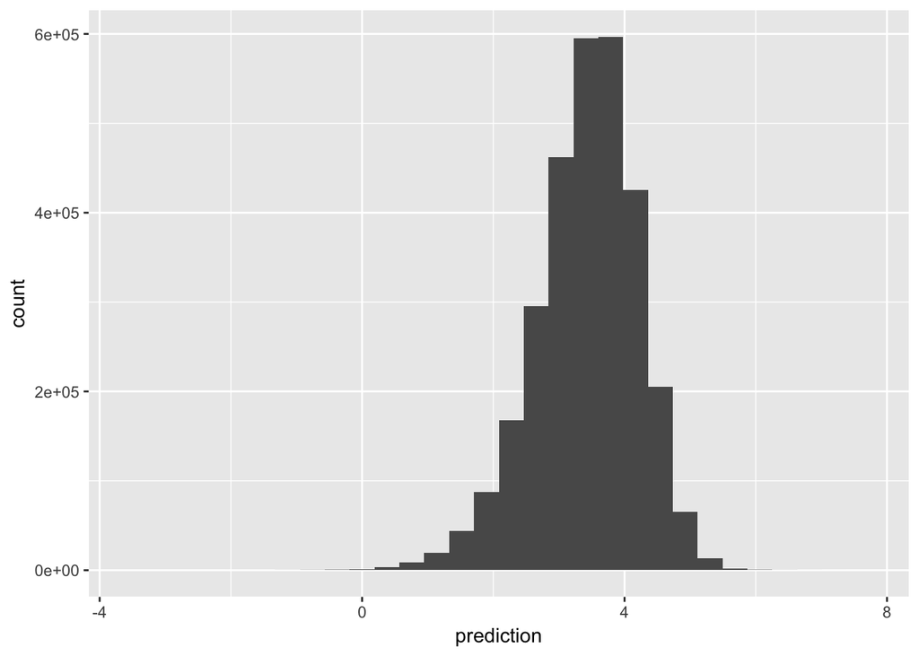

```r
ggplot(preds, aes(x = prediction)) + geom_histogram()
```

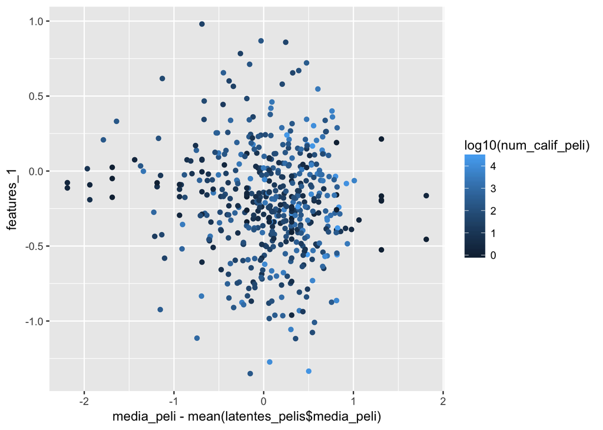

```r
latentes_pelis <- left_join(V_df,movies, by=c("id"="movieID")) %>%
                  left_join(medias_peliculas, by=c("id"="movieId"))

latentes_pelis <- latentes_pelis %>% mutate(num_grupo =
                                              ntile(num_calif_peli, 10))

ggplot(sample_n(latentes_pelis, 500), aes(y = features_1,
                           x = media_peli - mean(latentes_pelis$media_peli),
                           colour = log10(num_calif_peli))) +
  geom_point()
```

```r
arrange(latentes_pelis, features_2) %>%
  select(Title, features_2, media_peli, num_calif_peli) %>%
  filter(num_calif_peli > 500) %>%
  head(100)
```

```
## # A tibble: 100 x 4
##    Title                              features_2 media_peli num_calif_peli
##    <chr>                                   <dbl>      <dbl>          <int>
##  1 Star Wars: Episode IV - A New Hop~      -1.94       4.19          54502
##  2 Lord of the Rings: The Fellowship~      -1.85       4.14          37553
##  3 Lord of the Rings: The Return of ~      -1.85       4.14          31577
##  4 Star Wars: Episode V - The Empire~      -1.85       4.19          45313
##  5 Lord of the Rings: The Two Towers~      -1.82       4.11          33947
##  6 Captain America: The Winter Soldi~      -1.78       3.71           1261
##  7 Harry Potter and the Deathly Hall~      -1.74       3.95           3983
##  8 Autumn Tale, An (Conte d'automne)~      -1.73       3.70            528
##  9 Star Wars: Episode VI - Return of~      -1.73       4.00          46839
## 10 Matrix, The (1999)                      -1.72       4.19          51334
## # ... with 90 more rows
```

```r
preds$prediction[is.nan(preds$prediction)] <- mean(dat_entrena$rating)
preds %>% ungroup %>% summarise(error = recm(rating, prediction))
```

```
## # A tibble: 1 x 1
##   error
##   <dbl>
## 1 0.895
```

Una vez que tenemos todo lo deseado, desconectamos el clúster de *Spark*.

```r
sparklyr::spark_disconnect_all()
```

```
## [1] 1
```

4. Explica cómo hacer predicciones a partir del modelo (predicción de la calificación 1-5). ¿Qué películas recomendarías para el usuario usuario 4000 y el usuario 6000, y usuario 1333? (que no haya visto).

Para poder realizar recomendaciones a los usuarios basados en su historial de calificaciones, es necesario que, de las matrices obtenidas del modelo $U$ y $V$, tomemos el renglón correspondiente del usuario $i$ de la matriz de usuarios $U$, y la multipliquemos por la matríz de características de las películas $V$, para obtener el ranking de calificaciones para el usuario en particular.

Para conocer un poco más a los usuarios, observamos sus correspondientes renglones dentro de la matriz $U$ (los descriptores de estos).

```r
usuario <- 4000
as.matrix(U_df[U_df$id[usuario],3:12])
```

```
##      features_1 features_2 features_3 features_4 features_5 features_6
## [1,] -0.4735392 -0.9404991 0.05029014  -1.129697  -0.134617  0.5255801
##      features_7 features_8 features_9 features_10
## [1,] -0.4924031  0.2583781 0.01160908  -0.3004386
```

```r
usuario <- 6000
as.matrix(U_df[U_df$id[usuario],3:12])
```

```
##      features_1 features_2 features_3 features_4 features_5 features_6
## [1,] -0.1419389  -1.272228 -0.2598189  -1.395024  0.3459447  0.6351963
##       features_7 features_8 features_9 features_10
## [1,] -0.07252845  0.5375098 -0.2945294  -0.4477606
```

```r
usuario <- 1333
as.matrix(U_df[U_df$id[usuario],3:12])
```

```
##      features_1 features_2 features_3 features_4 features_5 features_6
## [1,] -0.1992622  -1.252216 -0.3657069 -0.9861326  0.4536572  0.6664487
##      features_7 features_8 features_9 features_10
## [1,] -0.5674306  0.4838759  0.3820229  -0.1714274
```

Como podemos observar, son usuarios bastante similares, por lo que sería de esperar que las recomendaciones de las películas fueran similares.

```r
# recomendaciones de películas para el usuario 4000
usuario <- 4000
as.matrix(U_df[U_df$id[usuario],3:12]) %*% t(as.matrix(V_df[,3:12])) %>%
  t() %>%
  cbind(V_df[,1]) %>%
  as.data.frame() %>%
  arrange(desc(.)) %>%
  # filtramos las películas que el usuario ya ha calificado
  anti_join(filter(usuarios_relevantes, userId == usuario), by = c("id" = "userId")) %>%
  head(n = 10) %>%
  left_join(select(movies, movieID, Title), by = c("id" = "movieID"))
```

```
##           .     id                                                 Title
## 1  4.365738  40697                                             Babylon 5
## 2  4.083427  99764                      It's Such a Beautiful Day (2012)
## 3  4.068085   5224                                       Promises (2001)
## 4  4.046570   2512     Ballad of Narayama, The (Narayama bushiko) (1983)
## 5  4.040377   2627                                      Endurance (1999)
## 6  4.028508  34435                                         Sholay (1975)
## 7  4.023724  81117                                Moth, The (Cma) (1980)
## 8  4.020507 107718                                  State of Play (2003)
## 9  4.019632   8785                  Early Summer (Bakushû) (1951)
## 10 4.005914  26073 Human Condition III, The (Ningen no joken III) (1961)
```

```r
# recomendaciones de películas para el usuario 6000
usuario <- 6000
as.matrix(U_df[U_df$id[usuario],3:12]) %*% t(as.matrix(V_df[,3:12])) %>%
  t() %>%
  cbind(V_df[,1]) %>%
  as.data.frame() %>%
  arrange(desc(.)) %>%
  # filtramos las películas que el usuario ya ha calificado
  anti_join(filter(usuarios_relevantes, userId == usuario), by = c("id" = "movieId")) %>%
  head(n = 10) %>%
  left_join(select(movies, movieID, Title), by = c("id" = "movieID"))
```

```
##           .     id
## 1  5.461626  61707
## 2  5.308998  40697
## 3  5.230467 101862
## 4  5.135543  99764
## 5  5.099692  77177
## 6  5.087696  34435
## 7  5.021673   5194
## 8  5.012292  92494
## 9  4.991340  47404
## 10 4.969793   6487
##                                                                               Title
## 1                                     Ladrón que roba a ladrón (2007)
## 2                                                                         Babylon 5
## 3                      50 Children: The Rescue Mission of Mr. And Mrs. Kraus (2013)
## 4                                                  It's Such a Beautiful Day (2012)
## 5                                                                 Wild China (2008)
## 6                                                                     Sholay (1975)
## 7  Who's Singin' Over There? (a.k.a. Who Sings Over There) (Ko to tamo peva) (1980)
## 8                                                       Dylan Moran: Monster (2004)
## 9                                                                  Mind Game (2004)
## 10                                                          Heart of Me, The (2002)
```

```r
# recomendaciones de películas para el usuario 1333
usuario <- 1333
as.matrix(U_df[U_df$id[usuario],3:12]) %*% t(as.matrix(V_df[,3:12])) %>%
  t() %>%
  cbind(V_df[,1]) %>%
  as.data.frame() %>%
  arrange(desc(.)) %>%
  # filtramos las películas que el usuario ya ha calificado
  anti_join(filter(usuarios_relevantes, userId == usuario), by = c("id" = "userId")) %>%
  head(n = 10) %>%
  left_join(select(movies, movieID, Title), by = c("id" = "movieID"))
```

```
##           .     id
## 1  5.319799 101862
## 2  4.951503  98595
## 3  4.789329  86237
## 4  4.768487  80111
## 5  4.714345 111130
## 6  4.694257   8455
## 7  4.691308  87719
## 8  4.679717  99675
## 9  4.679717 106048
## 10 4.665301  81117
##                                                           Title
## 1  50 Children: The Rescue Mission of Mr. And Mrs. Kraus (2013)
## 2                       Peppermint Soda (Diabolo menthe) (1977)
## 3                                            Connections (1978)
## 4                            Black Girl (La noire de...) (1966)
## 5                                          Powers of Ten (1977)
## 6                                     Long Way Home, The (1997)
## 7                                     Living with Wolves (2005)
## 8              Eat Sleep Die (Äta sova dö) (2012)
## 9                                      Four Days in July (1985)
## 10                                       Moth, The (Cma) (1980)
```